### Exploring the BRFSS dataset

*Entry date: 29-08-2019*

The following template is one provided by the Course itself. The exercise is split into three parts:

- Understanding the data
- Formulating three research questions
- Exploring the data - visually and through summary statistics

## Setup

### Load packages

```r
library(stats)
library(ggplot2)
library(tidyr)
library(dplyr)
library(reshape2)
```

### Load data

```r
load("brfss2013.RData")
```

## Part 1: Data

**Brief background of the BRFSS:**

- The Behavioral Risk Factor Surveillance System (BRFSS) is a collaborative project between all US states, participating US territories, and the CDC.
- The project is an ongoing surveillance system designed to measure behavioral risk factors of non-institutional adults aged 18 years and older who are residing in the US.
- It was initiated in the year 1984, and has 15 states collecting surveillance data on risk behaviors through monthly telephone interviews.
- It has been recorded an increasing number of survey participating states - by 2001, 50 states were participating in the BRFSS.
- Today, all 50 states collect data annually, with some states such as American Samoa, Federated States of Micronesia, and Palau collecting survey data once in every one to three months (limited point-in-time).

**Data collected:** Preventive health practices and risk behaviors linked to chronic diseases, injuries, and preventable infectious diseases affecting the adult population. For example, BRFSS 2013 assessed tobacco use, HIV/AIDS knowledge and prevention, exercise, immunization, health status, alcohol consumption, fruits and vegetables consumption, seatbelt use, and many more.

**Data collection method:** Landline telephone and cellular telephone based surveys.

- Landline telephone survey: Interviewers collect data from a randomly selected adult in a household
- Cellular telephone survey: Interviewers collect data from an adult who participates by using a cellular telephone and resides in a private residence or college housing

**Population target:** Non-institutionalised adult population aged 18 years or older who reside in the US.

**My understanding of the data and methods by which the data were collected:**

1. **Generalisability**: Random sampling was used in the landline telephone based conducted surveys where one adult in a household is randomly selected from the other adults presumably in the same household too. Random sampling means that every sample in a population, in this case, every adult in a household, stands an equal chance of being selected from the sample pool. This implies that results may be generalized across the population. However, there is no information regarding the selection method of the households. Are households randomly selected? If they are, then results from the randomly selected adults from the randomly selected households may be generalized across the population on a state-wide level. If households are not randomly selected, and/or if there are high non-response rates, then the data collected may potentially be biased.
2. **Causality**: This is an observational study, not an experimental study in which random assignments would have been involved. Thus, any relational-correlation does not imply causation.

## Part 2: Research questions

In this section, I am to come up with 3 research questions regarding the data collected.

First, let me have a look at what sort of data were collected, and to gauge the types of variables and relationships that I may question.

I want to look at the dimensions and all variables of the dataset.

```r
dim(brfss2013)
```

```
## [1] 491775    330
```

```r
names(brfss2013)
```

```
##   [1] "X_state"   "fmonth"    "idate"     "imonth"    "iday"      "iyear"
##   [7] "dispcode"  "seqno"     "X_psu"     "ctelenum"  "pvtresd1"  "colghous"
##  [13] "stateres"  "cellfon3"  "ladult"    "numadult"  "nummen"    "numwomen"
##  [19] "genhlth"   "physhlth"  "menthlth"  "poorhlth"  "hlthpln1"  "persdoc2"
##  [25] "medcost"   "checkup1"  "sleptim1"  "bphigh4"   "bpmeds"    "bloodcho"
##  [31] "cholchk"   "toldhi2"   "cvdinfr4"  "cvdcrhd4"  "cvdstrk3"  "asthma3"
##  [37] "asthnow"   "chcscncr"  "chcocncr"  "chccopd1"  "havarth3"  "addepev2"
##  [43] "chckidny"  "diabete3"  "veteran3"  "marital"   "children"  "educa"
##  [49] "employ1"   "income2"   "weight2"   "height3"   "numhhol2"  "numphon2"
##  [55] "cpdemo1"   "cpdemo4"   "internet"  "renthom1"  "sex"       "pregnant"
##  [61] "qlactlm2"  "useequip"  "blind"     "decide"    "diffwalk"  "diffdres"
##  [67] "diffalon"  "smoke100"  "smokday2"  "stopsmk2"  "lastsmk2"  "usenow3"
##  [73] "alcday5"   "avedrnk2"  "drnk3ge5"  "maxdrnks"  "fruitju1"  "fruit1"
##  [79] "fvbeans"   "fvgreen"   "fvorang"   "vegetab1"  "exerany2"  "exract11"
##  [85] "exeroft1"  "exerhmm1"  "exract21"  "exeroft2"  "exerhmm2"  "strength"
```

[output cut: 40 more lines]

There are so many (330) variables! Descriptions of all variables can be found here

**Research quesion 1:** Is there a relationship between sleeping adequacy and general health status amongst the adult population in the US?

*Rationale behind RQ1:* There is no particular reason why I chose these variables to investigate its relationship for. I thought it’d be interesting to see if people who are ‘healthy’ are also getting sufficient durations of sleep. Maybe the duration of one’s sleep contributes to one’s general health status. Or perhaps, the other way round.

**Research quesion 2:** Do people who perceive themselves as being treated differently compared to people of other races in their workplace, report experiencing depression and/or hopelessness?

*Rationale behind RQ2:* Although feelings of hopelessness and depression are not solely and may not even be contributed by poor (or better) treatments in workplaces, based on race, I am interested to see if there are discernible patterns of self reported feelings of mental illness/ stigma across different groups of people who perceived themselves as being treated better or worse than people of other races in their workplace.

**Research quesion 3:** What is the relationship between education levels and lifestyle patterns?

*Rationale behind RQ3:* I want to explore Numerical, continuous variables this time.

## Part 3: Exploratory data analysis

I will now explore each research question - first, visually, then using simple summary statistics.

**Research quesion 1:** Is there a relationship between sleeping adequacy (variable name: sleptim1) and general health status (variable name: genhlth) amongst the adult population in the US?

Survey questions for the above variables:

1. sleptim1: On average, how many hours of sleep do you get in a 24-hour period? *Responses: 1 - 24; Don’t know; Missing*
2. genhlth: Would you say that in general, your health is *Responses: Excellent; Very good; Good; Fair; Poor; Don’t know; Refused; Missing*

First, I create a new dataframe only containing the necessary variables. I also keep the first column on state names.

```r
#extract the correct columns
sleep_genhlth <- brfss2013 %>% select(c("X_state","sleptim1","genhlth"))

#get a summary picture of the three variables
str(sleep_genhlth)
```

```
## 'data.frame':    491775 obs. of  3 variables:
##  $ X_state : Factor w/ 55 levels "0","Alabama",..: 2 2 2 2 2 2 2 2 2 2 ...
##  $ sleptim1: int  NA 6 9 8 6 8 7 6 8 8 ...
##  $ genhlth : Factor w/ 5 levels "Excellent","Very good",..: 4 3 3 2 3 2 4 3 1 3 ...
```

```r
summary(sleep_genhlth)
```

```
##           X_state          sleptim1            genhlth
##  Florida      : 33668   Min.   :  0.000   Excellent: 85482
##  Kansas       : 23282   1st Qu.:  6.000   Very good:159076
##  Nebraska     : 17139   Median :  7.000   Good     :150555
##  Massachusetts: 15071   Mean   :  7.052   Fair     : 66726
##  Minnesota    : 14340   3rd Qu.:  8.000   Poor     : 27951
##  New Jersey   : 13776   Max.   :450.000   NA's     :  1985
##  (Other)      :374499   NA's   :7387
```

The variable General health status is a Factor variable, whereas Sleep time is a Numerical (continuous) variable with the latter showcasing number of hours slept.

There are 1,985 and 7,387 missing values under General health status and Sleep time, respectively. I will remove all rows with missing values.

```r
sleep_genhlth <- sleep_genhlth %>% filter(!is.na(sleptim1) & !is.na(genhlth))
```

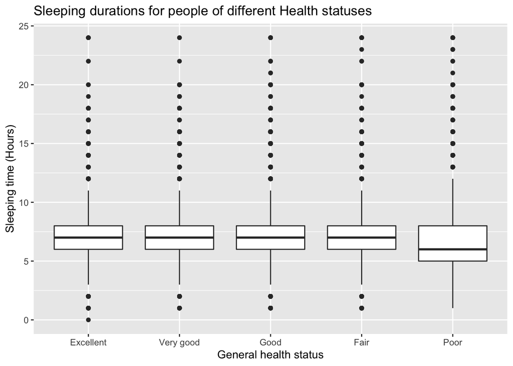

```r
ggplot(sleep_genhlth, aes(x=genhlth, y=sleptim1)) + geom_boxplot() + ggtitle("Sleeping durations for people of different Health statuses") + xlab("General health status") + ylab("Sleeping time (Hours)")
```

**Description of graph(s):** The average/ mean Sleeping time hours are largely similar across all groups of General health status, with the first four displaying almost equal averages (from the outset) and the last group (General health status: Poor) showing a slightly lower average.

The third-quartiles, meaning 75% of people, of every group, sleep for similar hours, whereas the first-quartiles, 25% of people, who are Poor in their health status have slightly lesser hours of sleep compared with 25% of people who are not poor in health.

All in all, there seems to be a lack of relationship between Sleep time and General health status - all box plots share many overlapping Sleep time values.

I will now look at the **summary statistics** for both of these variables. In a way, summary statistics and their display of numbers serve to validate the graphical representations of data. I will group the summary statistics according to General health status.

```r
sleep_genhlth %>% group_by(genhlth) %>% summarise(count=n(),mean_sleep=mean(sleptim1),median_sleep=median((sleptim1)))
```

```
## # A tibble: 5 x 4
##   genhlth    count mean_sleep median_sleep
## * <fct>      <int>      <dbl>        <dbl>
## 1 Excellent  84822       7.19            7
## 2 Very good 157833       7.10            7
## 3 Good      148299       7.04            7
## 4 Fair       65012       6.90            7
## 5 Poor       26639       6.74            6
```

The table above shows me that true enough, the mean and median values for Sleep time are largely similar across all groups. Even for those with Poor health, most people get 6 hours of sleep throughout a 24 hour period.

**Conclusion:** No matter the General health status (amid self-reported) of the adult population in the US (amid a questionable whole-population generalizability), duration of Sleep time remains mostly similar amongst a majority of people.

**Research quesion 2:** Do people who perceive themselves as being treated differently compared to people of other races in their workplace (variable name: rratwrk2), report experiencing depression and hopelessness (variable names: misdeprd and mishopls)?

Survey questions for the above variables:

1. rratwrk2: Within the past 12 months at work, do you feel you were treated worse than, the same as, or better than people of other races? *Responses: Worse than other races; Same as other races; Better than other races; Worse than some, better than others; Only encountered people of the same race; Don’t know; Refused; Missing*
2. misdeprd: During the past 30 days, about how often did you feel so depressed that nothing could cheer you up? *Responses: All; Most; Some; A little; None; Don’t know; Refused; Missing*
3. mishopls: During the past 30 days, about how often did you feel hopeless that nothing could cheer you up? *Responses: All; Most; Some; A little; None; Don’t know; Refused; Missing*

Similar to before, I obtain a second dataframe containing the three variables of self-perceived workplace treatment, feelings of hopelessness, and depression.

```r
race_mentalhlth <- brfss2013 %>% select(c("X_state","rratwrk2","misdeprd", "mishopls"))

#explore dataset
str(race_mentalhlth)
```

```
## 'data.frame':    491775 obs. of  4 variables:
##  $ X_state : Factor w/ 55 levels "0","Alabama",..: 2 2 2 2 2 2 2 2 2 2 ...
##  $ rratwrk2: Factor w/ 5 levels "Worse than other races",..: NA 2 2 NA NA NA NA NA NA NA ...
##  $ misdeprd: Factor w/ 5 levels "All","Most","Some",..: 5 5 5 5 NA NA NA NA NA NA ...
##  $ mishopls: Factor w/ 5 levels "All","Most","Some",..: 3 5 5 5 NA NA NA NA NA NA ...
```

```r
summary(race_mentalhlth)
```

```
##           X_state                                            rratwrk2
##  Florida      : 33668   Worse than other races                   :    76
##  Kansas       : 23282   The same as other races                  :  1377
##  Nebraska     : 17139   Better than other races                  :    69
##  Massachusetts: 15071   Worse than some races, better than others:     3
##  Minnesota    : 14340   Only encountered people of the same race :    12
##  New Jersey   : 13776   NA's                                     :490238
##  (Other)      :374499
##      misdeprd          mishopls
##  All     :   259   All     :   346
##  Most    :   539   Most    :   625
##  Some    :  1567   Some    :  2200
##  A little:  2539   A little:  3762
##  None    : 31202   None    : 29227
##  NA's    :455669   NA's    :455615
##
```

All variables are Factor variables. As for missing values or non-responses - there are 490,238 NAs, 455,669 NAs, and 455,615 NAs for Survey questions of ‘How do you feel you were treated at work compared to people of other races?’, ‘How often feel depressed past 30 days’, and ‘How often feel hopeless past 30 days’, respectively. I will now remove all missing values, and see what I am left with for analysis.

```r
race_mentalhlth <- race_mentalhlth%>%filter(!is.na(rratwrk2)&!is.na(misdeprd)&!is.na(mishopls))
```

From an initial dataframe of 491,775 rows/ observations/ cases, I am left with 169 observations - 491,606 observations had at least one missing value from either one of the three variables.

I will now plot basic bar charts to visualise the frequencies of survey answers from respondents.

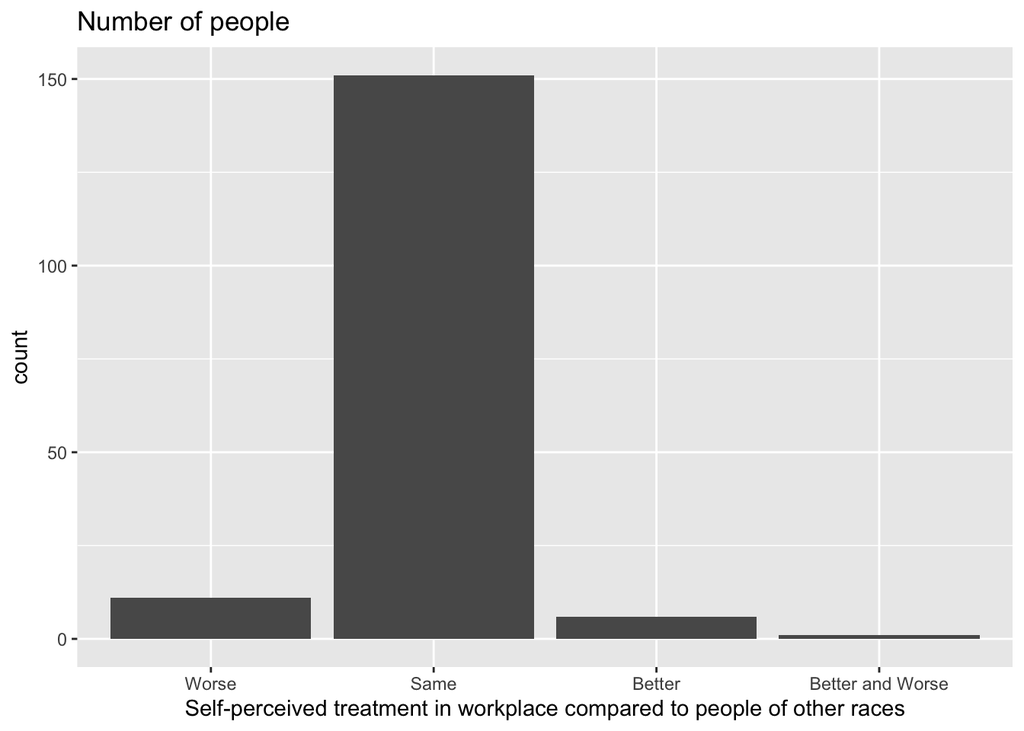

```r
#for self-perceived workplace treatment
ggplot(race_mentalhlth,aes(x=rratwrk2))+geom_bar()+scale_x_discrete(labels=c("Worse","Same","Better","Better and Worse")) + ggtitle("Number of people") + xlab("Self-perceived treatment in workplace compared to people of other races")
```

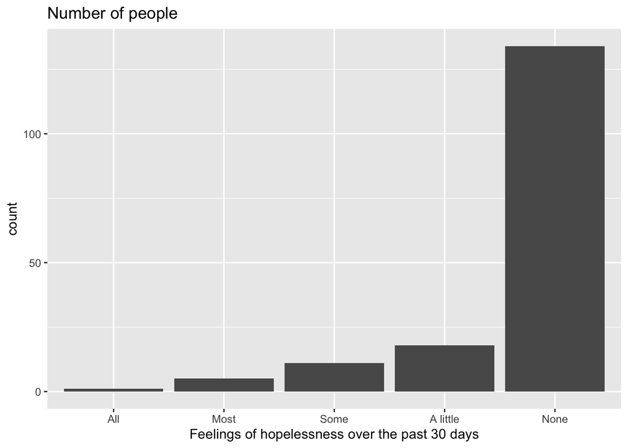

```r
#for feeling of hopelessness
ggplot(race_mentalhlth, aes(x=mishopls)) + geom_bar() + ggtitle("Number of people") + xlab("Feelings of hopelessness over the past 30 days")
```

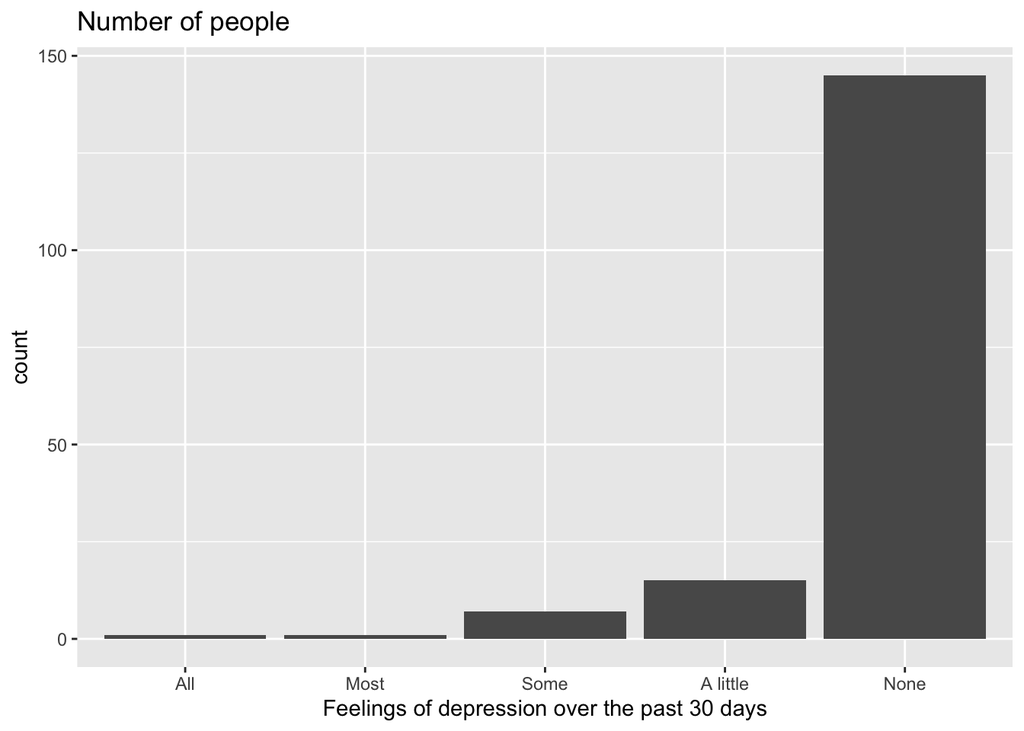

```r
#for feeling of depression
ggplot(race_mentalhlth, aes(x=misdeprd)) + geom_bar() + ggtitle("Number of people")+xlab("Feelings of depression over the past 30 days")
```

**Description of graph(s):** Most survey respondents perceived that they were treated equally as people of other races. Similarly, most survey respondents reported no sense of hopelessness and depression *at all* throughout the past 30 days.

Next, I want to overlay these data on a single graph, to observe the spread of self-reported hopelessness and depression across the different groups of self-perceived workplace treatment.

Because I want to gauge how many of those within each group of self-perceived workplace treatment felt hopeless or depressed, as well as compare them across the different groups, I calculate percentages/ proportions of not-hopeless-hopeless and not-depressed-depressed within each group of self-perceived workplace treatment. If I merely use counts/ numbers of people, as opposed to proportions, I would be disregarding the fact there is a disproportionately larger number of respondents who perceived that they were treated the same as other races in their workplace. Using mere number counts disables me from making standardized comparisons across the different groups. This entire process involves a few steps:

```r
#make tables and proportion tables
table1 <- table(race_mentalhlth$rratwrk2, race_mentalhlth$mishopls)
proptable1 <- prop.table(table1, margin=1)

#convert table into a dataframe
prop_race_hopeless <- as.data.frame.matrix(proptable1)
prop_race_hopeless$Self_percp_of_race_treat_workplace <- rownames(prop_race_hopeless)

#modify dataframe into a long format
prop_race_hopeless <- melt(prop_race_hopeless,id.vars=c("Self_percp_of_race_treat_workplace"),value.name="proportion")%>%rename(Feeling_hopeless = variable)
```

Now, for the other variable:

```r
#make tables and proportion tables
table2 <- table(race_mentalhlth$rratwrk2, race_mentalhlth$misdeprd)
proptable2 <- prop.table(table2, margin=1)

#convert table into a dataframe
prop_race_depressed <- as.data.frame.matrix(proptable2)
prop_race_depressed$Self_percp_of_race_treat_workplace <-rownames(prop_race_depressed)

#modify dataframe into a long format
prop_race_depressed <- melt(prop_race_depressed,id.vars=c("Self_percp_of_race_treat_workplace"),value.name="proportion") %>% rename(Feeling_depressed = variable)
```

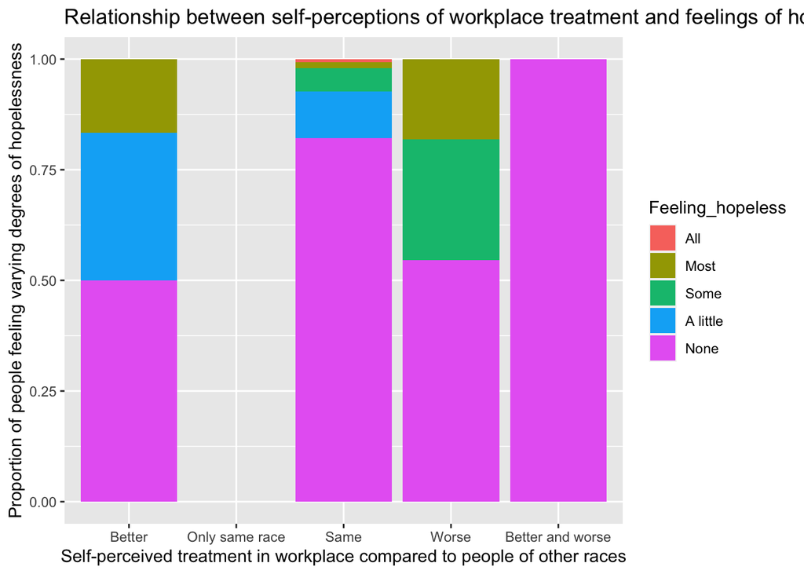

```r
#box plot showing proportion of peoples' feelings of hopelessness (or not) based on their self-perception of being racially discriminated against (or not) in their workplace
ggplot(prop_race_hopeless, aes(x=Self_percp_of_race_treat_workplace,y=proportion,fill=Feeling_hopeless)) + geom_bar(stat="identity") + scale_x_discrete(labels=c("Better","Only same race","Same","Worse","Better and worse")) + ggtitle("Relationship between self-perceptions of workplace treatment and feelings of hopelessness") + xlab("Self-perceived treatment in workplace compared to people of other races") + ylab("Proportion of people feeling varying degrees of hopelessness")
```

**Description of graph(s):**

It is difficult to draw any conclusions from this graph, as perhaps the sample size is too small (n=169) for the deducing of any results. However, taking into account these limitations, it seems like the feeling of hopelessness cannot be solely explained by workplace treatment, as regardless of whether people perceived that they were treated better, the same, or worse than others of other races, there are people from all groups who reported feeling hopeless.

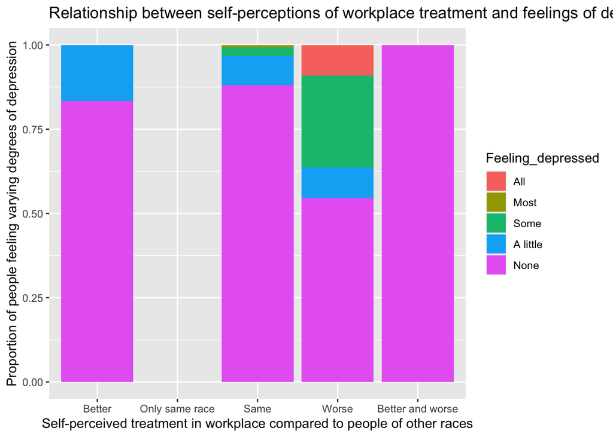

```r
#box plot showing proportion of peoples' feelings of depression (or not) based on their self-perception of being racially discriminated against (or not) in their workplace
ggplot(prop_race_depressed, aes(x=Self_percp_of_race_treat_workplace, y=proportion, fill=Feeling_depressed)) + geom_bar(stat="identity") + scale_x_discrete(labels=c("Better","Only same race","Same","Worse","Better and worse")) + ggtitle("Relationship between self-perceptions of workplace treatment and feelings of depression") + xlab("Self-perceived treatment in workplace compared to people of other races") + ylab("Proportion of people feeling varying degrees of depression")
```

**Description of graph(s):** Similar to the previous plot, a majority of people felt no depression *at all* throughout the past 30 days during which the survey was conducted then. Patterns of depression intensity/ spread are mostly, vaguely (at least from the outset), similar to patterns of hopelessness intensity/ spread too. The only obvious difference between both plots is that where amongst people who perceived themselves as being treated worse, there are those who also reported feeling depressed *all the time*, whereas none reported feeling hopeless *all the time*. All these observations seem to me pretty inconsequential at the moment.

All in all, in regards to answering research question 2 (Do people who perceive themselves as being treated differently compared to people of other races in their workplace, report experiencing depression and hopelessness?) - yes, people who perceived themselves as being treated better or worse also reported themselves as feeling hopeless and depressed (at varying degrees). However, feelings of hopelessness and depression are not only exclusive amongst people who felt as if they were treated differenly - people who perceived same treatment also felt hopeless and depressed (although at a smaller percentage as a whole). In short, feelings of hopelessness and depression do not seem to correlate with differing self-perceptions of workplace treatment.

Summary statistics would be able to reveal a more accurate insight to the actual numbers of proportions:

```r
summary(race_mentalhlth)
```

```
##      X_state                                         rratwrk2       misdeprd
##  Alabama :168   Worse than other races                   : 11   All     :  1
##  Maine   :  1   The same as other races                  :151   Most    :  1
##  0       :  0   Better than other races                  :  6   Some    :  7
##  Alaska  :  0   Worse than some races, better than others:  1   A little: 15
##  Arizona :  0   Only encountered people of the same race :  0   None    :145
##  Arkansas:  0
##  (Other) :  0
##      mishopls
##  All     :  1
##  Most    :  5
##  Some    : 11
##  A little: 18
##  None    :134
##
##
```

```r
#hopelessness
prop.table(table1, margin=1)
```

```
##
##                                                     All        Most        Some
##   Worse than other races                    0.000000000 0.181818182 0.272727273
##   The same as other races                   0.006622517 0.013245033 0.052980132
##   Better than other races                   0.000000000 0.166666667 0.000000000
##   Worse than some races, better than others 0.000000000 0.000000000 0.000000000
##   Only encountered people of the same race
##
##                                                A little        None
##   Worse than other races                    0.000000000 0.545454545
##   The same as other races                   0.105960265 0.821192053
##   Better than other races                   0.333333333 0.500000000
##   Worse than some races, better than others 0.000000000 1.000000000
##   Only encountered people of the same race
```

82.1% of people who perceived that they were treated equally in their workplace felt no hopelessness *at all*. Amongst those who perceived that they were receiving better or worse workplace treatment, at least half of each group felt no hopelessness *at all*, and a small minority of them feeling hopeless *most* and *a little* of the time.

```r
#depression
prop.table(table2, margin=1)
```

```
##
##                                                     All        Most        Some
##   Worse than other races                    0.090909091 0.000000000 0.272727273
##   The same as other races                   0.000000000 0.006622517 0.026490066
##   Better than other races                   0.000000000 0.000000000 0.000000000
##   Worse than some races, better than others 0.000000000 0.000000000 0.000000000
##   Only encountered people of the same race
##
##                                                A little        None
##   Worse than other races                    0.090909091 0.545454545
##   The same as other races                   0.086092715 0.880794702
##   Better than other races                   0.166666667 0.833333333
##   Worse than some races, better than others 0.000000000 1.000000000
##   Only encountered people of the same race
```

88.1% of people who perceived that they were treated equally in their workplace felt no depression *at all*. I observe no immediately dissimilar patterns in the results across both tables.

**Research quesion 3:** What is the relationship between education levels (Variable name: educa) and lifestyle patterns (Variable names: ssbsugar, exeroft1)?

Survey questions for the above variables:

1. educa: What is the highest grade or year of school you completed? *Responses: Never attended school or any kindergarden; Grades 1 through 8 (Elementary); Grades 9 through 11 (Some high school); Grade 12 or GED (High school graduate); College 1 year to 3 years (Some college); College 4 years or more (College graduate); Refused; Missing*
2. ssbsugar: During the past 30 days, how often did you drink regular soda or pop that contains sugar? *Responses: x times per day; per week; per month; Don’t know; Never; Refused; Missing*
3. exeroft1: How many times per week or per month did you take part in this activity during the past month? *Responses: x times per day; per week; per month; Don’t know; Never; Refused; Missing*

Similar to the first two, I will now create a dataframe of the necessary variables.

```r
edu_lifestyle <- brfss2013 %>% select(c("X_state","educa","ssbsugar","exeroft1"))

#rename variable names for easier reading
edu_lifestyle <- edu_lifestyle%>%rename(education_levels=educa,soda_pop=ssbsugar,exercise=exeroft1)

str(edu_lifestyle)
```

```
## 'data.frame':    491775 obs. of  4 variables:
##  $ X_state         : Factor w/ 55 levels "0","Alabama",..: 2 2 2 2 2 2 2 2 2 2 ...
##  $ education_levels: Factor w/ 6 levels "Never attended school or only kindergarten",..: 6 5 6 4 6 6 4 5 6 4 ...
##  $ soda_pop        : int  305 203 202 203 NA NA NA NA NA NA ...
##  $ exercise        : int  NA 105 NA 205 NA 102 220 102 102 220 ...
```

```r
summary(edu_lifestyle)
```

```
##           X_state
##  Florida      : 33668
##  Kansas       : 23282
##  Nebraska     : 17139
##  Massachusetts: 15071
##  Minnesota    : 14340
##  New Jersey   : 13776
##  (Other)      :374499
##                                                      education_levels
##  Never attended school or only kindergarten                  :   677
##  Grades 1 through 8 (Elementary)                             : 13395
##  Grades 9 though 11 (Some high school)                       : 28141
##  Grade 12 or GED (High school graduate)                      :142971
##  College 1 year to 3 years (Some college or technical school):134197
##  College 4 years or more (College graduate)                  :170120
##  NA's                                                        :  2274
##     soda_pop         exercise
##  Min.   :  0      Min.   :  0.0
##  1st Qu.:  0      1st Qu.:103.0
##  Median :101      Median :105.0
##  Mean   :124      Mean   :135.8
##  3rd Qu.:301      3rd Qu.:203.0
##  Max.   :399      Max.   :299.0
##  NA's   :388580   NA's   :164165
```

```r
sum(is.na(edu_lifestyle))
```

```
## [1] 555019
```

```r
#remove all missing values
edu_lifestyle <-  na.omit(edu_lifestyle)
```

When analysing and interpreting the values stored under each Numerical variable, it is imporant to note that the values are not what they mean - in terms answering the survey questions. Notice that most values are three-digits. This does not mean that respondents consumed 200+ soda drinks in any given day, week, or month.

As per BRFSS Data description, the digits are coded with different underlying meanings. The first digit indicates the number of times *per day*, *per week*, or *per month*. 1 as the first digit indicates *per day*, 2 indicates *per week*, and 3 indicates *per month* . This pattern is true for variable soda_pop.

For variable exercise, there are only two levels to the pattern. 1 as the first digit indicates *per week* and 2 indicates *per month*

I feel like I have unnecessarily inconvenienced myself with this Coursera exercise, which by the way I read was only supposed to take 2 hours, by picking these variables for my third research question… because I would now have to clean the variables before an accurate analysis of data can happen…

So… here goes…

```r
#to use some functions under the tidyverse package
library(tidyverse)
#identify number of values under soda variable with first digits of 1, 2, and 3

#for three digit values starting with 1
sum(str_detect(edu_lifestyle$soda_pop, "^[1][0-9]{2}$")) #8,915 in total
```

```
## [1] 8915
```

```r
#for three digit values starting with 2
sum(str_detect(edu_lifestyle$soda_pop, "^[2][0-9]{2}$")) #11,548 in total
```

```
## [1] 11548
```

```r
#for three digit values starting with 3
sum(str_detect(edu_lifestyle$soda_pop, "^[3][0-9]{2}$")) #19,456 in total
```

```
## [1] 19456
```

```r
#for values without the three digit pattern, not inclusive of single digit 0s as
#they indicate 'never'
sum(str_detect(edu_lifestyle$soda_pop,"^[1-9]{1,2}$")) #0 in total
```

```
## [1] 0
```

```r
#for single digit values starting with 0
sum(str_detect(edu_lifestyle$soda_pop,"^[0]{1}$")) #34,182 in total
```

```
## [1] 34182
```

```r
#all the above values add up to 74,101

#identify number of values under variable exercise with first digits of 1, 2, and 3

#for single digit values starting with 1
sum(str_detect(edu_lifestyle$exercise, "^[1][0-9]{2}$")) #52,854 in total
```

```
## [1] 52854
```

```r
#for single digit values starting with 2
sum(str_detect(edu_lifestyle$exercise, "^[2][0-9]{2}$")) #21,245 in total
```

```
## [1] 21245
```

```r
#for values without the three digit pattern, not inclusive of single digit 0s as
#they indicate 'never'
sum(str_detect(edu_lifestyle$exercise,"^[1-9]{1,2}$")) #2 in total
```

```
## [1] 2
```

```r
#for single digit values starting with 0
sum(str_detect(edu_lifestyle$exercise,"^[0]{1}$")) #0
```

```
## [1] 0
```

```r
#the above values add up to 74,101. values without the three digit patterns that are
#not inclusive of single digits 0s are shown below
str_subset(edu_lifestyle$exercise,"^[1-9]{1,2}$") # 13 and 2
```

```
## [1] "13" "2"
```

```r
#i will remove values 13 and 2 because i am unsure what both values were intended to
#mean by the respondents
edu_lifestyle <- edu_lifestyle %>% filter(!exercise==13 & !exercise==2)

#create a function to add an apostrophe between the first digit and the rest.
#This is to distinguish the first digit code meant for indicating day, week, or
#month, and the second and third combined for indicating count, as well as for easier
#separation later on. I want the function to also add an apostrophe after the 0 digit,
#and add another 0 after the apostrophe. This is for format standardization.
reformat <- function(x){x%>%str_replace_all("^([1,2,3])(\\d+)$","\\1'\\2")%>%str_replace_all("^(0)$","\\1'0")}

#apply the function to variables
soda_pop_reformat <- reformat(edu_lifestyle$soda_pop)

exercise_reformat <- reformat(edu_lifestyle$exercise)

#add new column to df to incorporate the above reformatted values
edu_lifestyle <- edu_lifestyle%>%mutate(soda_pop_reformat=soda_pop_reformat,exercise_reformat=exercise_reformat)

#separate digits into new variables of timeframe and count
edu_lifestyle <- edu_lifestyle%>%separate(soda_pop_reformat,c("timeframe_soda","count_soda"))%>%separate(exercise_reformat,c("timeframe_exercise","count_exercise"))

#label numerically-coded values of timeframes as 'per day','per week', or 'per month'
edu_lifestyle <- mutate(edu_lifestyle,timeframe_soda=ifelse(timeframe_soda==0,"never",ifelse(timeframe_soda==1,"day",ifelse(timeframe_soda==2,"week",ifelse(timeframe_soda==3,"month","others")))),timeframe_exercise=ifelse(timeframe_exercise==1,"week",ifelse(timeframe_exercise==2,"month","others")))

#remove all first digit 0s under variable count
edu_lifestyle <- edu_lifestyle%>%mutate(count_soda=str_replace_all(edu_lifestyle$count_soda,"^(0)([1-9]{1}$)", "\\2"),count_exercise=str_replace_all(edu_lifestyle$count_exercise,"^(0)([1-9]{1})$", "\\2"))

#remove original variables that have now become redundant since reformatting
edu_lifestyle <- edu_lifestyle %>% select(-c(soda_pop,exercise))

str(edu_lifestyle)
```

```
## 'data.frame':    74099 obs. of  6 variables:
##  $ X_state           : Factor w/ 55 levels "0","Alabama",..: 2 2 2 2 2 2 2 2 2 2 ...
##  $ education_levels  : Factor w/ 6 levels "Never attended school or only kindergarten",..: 5 4 3 6 6 4 5 5 6 5 ...
##  $ timeframe_soda    : chr  "week" "week" "day" "never" ...
##  $ count_soda        : chr  "3" "3" "2" "0" ...
##  $ timeframe_exercise: chr  "week" "month" "week" "week" ...
##  $ count_exercise    : chr  "5" "5" "1" "2" ...
```

```r
#convert Character variables into Numerical
edu_lifestyle <- edu_lifestyle%>%mutate(count_soda=as.numeric(count_soda),count_exercise=as.numeric(count_exercise))

#standardize all values to per month bases - calculate as necessary according to its original base
#(per day or per week). calculations will be mere approximations.
edu_lifestyle <- mutate(edu_lifestyle,count_soda=ifelse(timeframe_soda=="day",count_soda*30,ifelse(timeframe_soda=="week",count_soda*4,ifelse(timeframe_soda=="month",count_soda,ifelse(timeframe_soda=="never",count_soda,"others")))),count_exercise=ifelse(timeframe_exercise=="day",count_exercise*30,ifelse(timeframe_exercise=="week",count_exercise*4,ifelse(timeframe_exercise=="month",count_exercise,ifelse(timeframe_exercise=="never",count_exercise,"others")))))

#organize and clean variable columns
edu_lifestyle <- edu_lifestyle%>%select(-c(timeframe_soda,timeframe_exercise))%>%rename(soda_permonth=count_soda,exercise_permonth=count_exercise)

edu_lifestyle <- edu_lifestyle%>%mutate(soda_permonth=as.numeric(soda_permonth),exercise_permonth=as.numeric(exercise_permonth))
```

I believe I have obtained the correctly arranged dataframe:

```r
head(edu_lifestyle,n=10)
```

```
##    X_state                                             education_levels
## 1  Alabama College 1 year to 3 years (Some college or technical school)
## 2  Alabama                       Grade 12 or GED (High school graduate)
## 3  Alabama                        Grades 9 though 11 (Some high school)
## 4  Alabama                   College 4 years or more (College graduate)
## 5  Alabama                   College 4 years or more (College graduate)
## 6  Alabama                       Grade 12 or GED (High school graduate)
## 7  Alabama College 1 year to 3 years (Some college or technical school)
## 8  Alabama College 1 year to 3 years (Some college or technical school)
## 9  Alabama                   College 4 years or more (College graduate)
## 10 Alabama College 1 year to 3 years (Some college or technical school)
##    soda_permonth exercise_permonth
## 1             12                20
## 2             12                 5
## 3             60                 4
## 4              0                 8
## 5              0                28
## 6              0                20
## 7              1                12
## 8              0                16
## 9              6                28
## 10             0                20
```

Now I can begin plotting away!

Several plots that I can think of as follows:

**1. Distribution of monthly soda consumption frequencies across education levels**

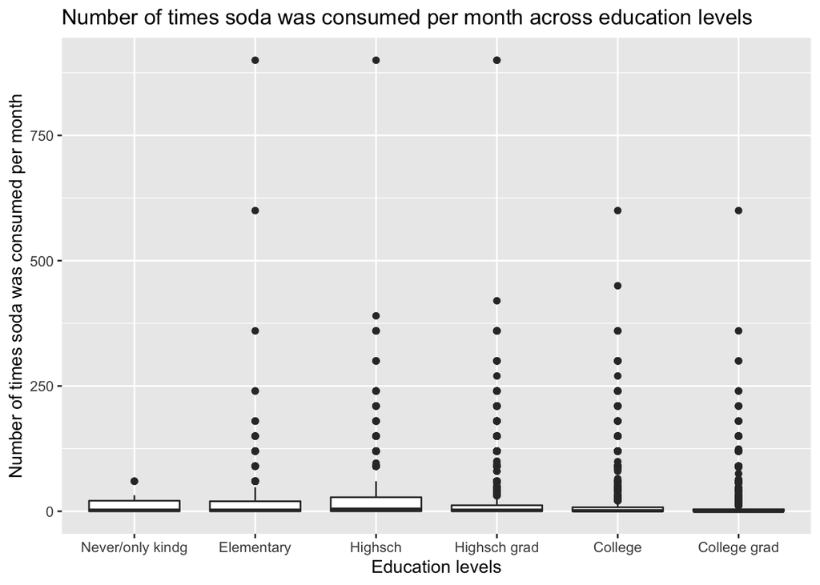

```r
ggplot(edu_lifestyle,aes(x=education_levels,y=soda_permonth))+geom_boxplot()+scale_x_discrete(labels=c("Never/only kindg","Elementary","Highsch","Highsch grad","College","College grad"))+ggtitle("Number of times soda was consumed per month across education levels")+xlab("Education levels")+ylab("Number of times soda was consumed per month")
```

**Description of graph(s):** The averages of soda consumption frequencies per month are roughly similar across all education levels. The interquartile range (IQR) for the first three education levels are roughly similar to one another, whereas the IQR for the last three are roughly similar to one another. IQR is larger in the first three as compared to the last three.

There is only one outlier in the first education level group. As with the remaining five levels, there is a considerable number of outliers of similar range - outliers meaning observations that are numerically distant from the majority of the data. Overall, most of the data within each education level overlap with one another.

**2. Distribution of monthly exercise frequencies across education levels**

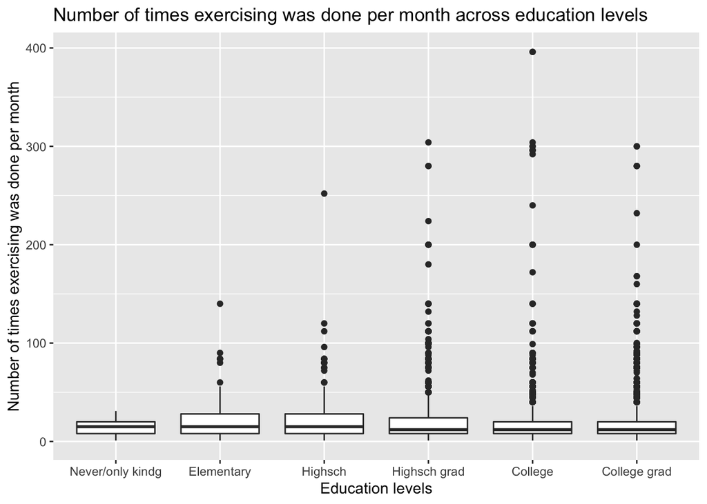

```r
ggplot(edu_lifestyle,aes(x=education_levels,y=exercise_permonth))+geom_boxplot()+scale_x_discrete(labels=c("Never/only kindg","Elementary","Highsch","Highsch grad","College","College grad"))+ggtitle("Number of times exercising was done per month across education levels")+xlab("Education levels")+ylab("Number of times exercising was done per month")
```

**Description of graph(s):** The averages of exercise frequencies per month also look vaguely similar across all education levels, with most of the data within each group overlapping with one another too.

There are no outliers in the first education group, whereas the remaining groups have considerable amount of outliers. Out of all outliers, one stand out most, and that is a college student’s close to 400 times of exercising done per month.

**3. Relationship between monthly frequencies of soda consumption and exercise stratified according to education levels (in multiple plots)**

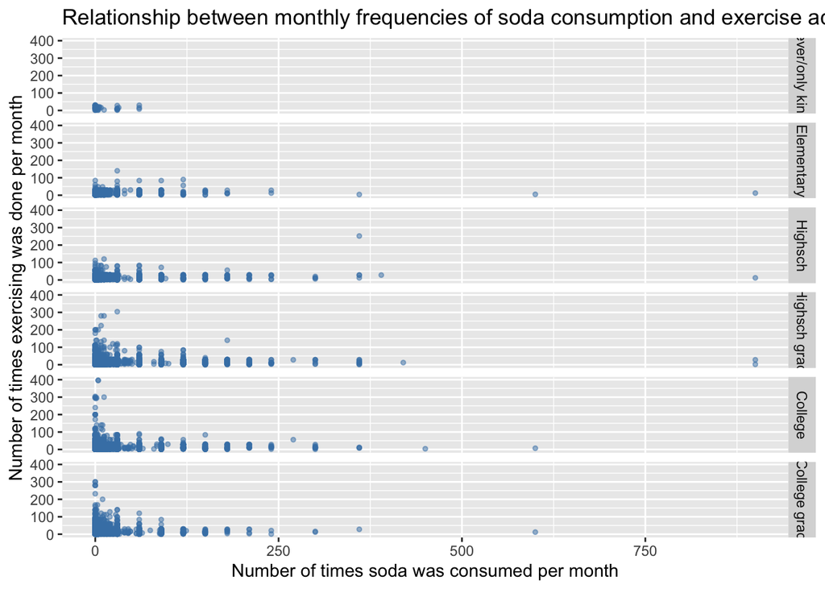

```r
ggplot(edu_lifestyle,aes(x=soda_permonth,y=exercise_permonth))+geom_point(color='steelblue',size=1.0,alpha=0.5)+facet_grid(education_levels~.,labeller=as_labeller(c("Never attended school or only kindergarten"="Never/only kindg","Grades 1 through 8 (Elementary)"="Elementary","Grades 9 though 11 (Some high school)"="Highsch","Grade 12 or GED (High school graduate)"="Highsch grad","College 1 year to 3 years (Some college or technical school)"="College","College 4 years or more (College graduate)"="College grad")))+ggtitle("Relationship between monthly frequencies of soda consumption and exercise according to education levels")+xlab("Number of times soda was consumed per month")+ylab("Number of times exercising was done per month")
```

**Description of graph(s):** Visually, it looks like amongst those who have never had any form of education or those whose education level pertained to attending kindergarden only, do not consist of people who consume soda and exercise at ‘extreme’ frequencies. Other than that, it doesnt seem like a strong relationship exist between frequencies of soda consumption exercise across educational levels, even when take as a whole.

**4. Relationship between monthly frequencies of soda consumption and exercise stratified according to education levels (in single plot - color coded)**

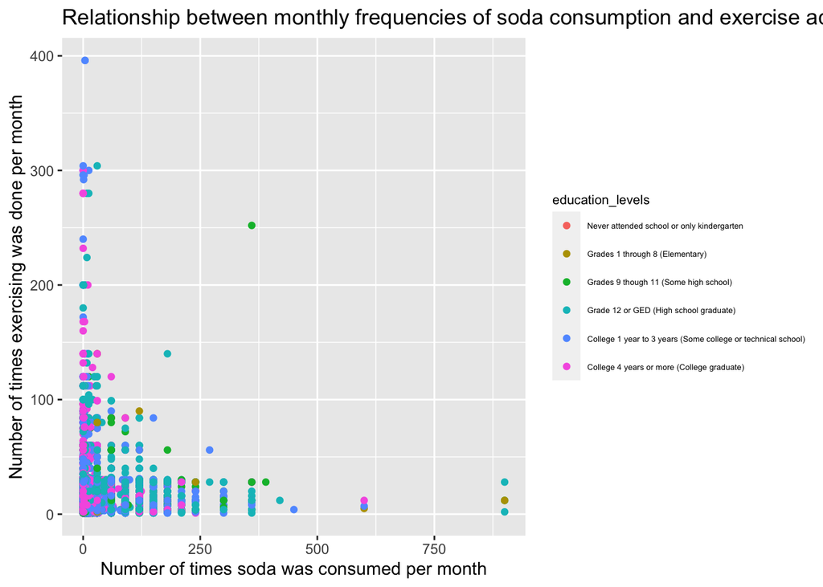

```r
ggplot(edu_lifestyle,aes(soda_permonth,exercise_permonth,color=education_levels))+geom_point()+theme(legend.title=element_text(size=8),legend.text=element_text(size=5))+ggtitle("Relationship between monthly frequencies of soda consumption and exercise according to education levels")+xlab("Number of times soda was consumed per month")+ylab("Number of times exercising was done per month")
```

Now to calculate some summary statistics.

```r
sum_stats_soda <- edu_lifestyle%>%select(-X_state)%>%group_by(education_levels)%>%summarise(num_ppl=n(),total_soda=sum(soda_permonth),mean=mean(soda_permonth),median=median(soda_permonth),iqr=IQR(soda_permonth),Q1=quantile(soda_permonth,0.25),Q3=quantile(soda_permonth,0.75))

head(sum_stats_soda,n=10)
```

```
## # A tibble: 6 x 8
##   education_levels             num_ppl total_soda  mean median   iqr    Q1    Q3
##   <fct>                          <int>      <dbl> <dbl>  <dbl> <dbl> <dbl> <dbl>
## 1 Never attended school or on…      43        478 11.1       2    21     0    21
## 2 Grades 1 through 8 (Element…    1143      18522 16.2       2    20     0    20
## 3 Grades 9 though 11 (Some hi…    3084      56357 18.3       4    28     0    28
## 4 Grade 12 or GED (High schoo…   18566     242750 13.1       2    12     0    12
## 5 College 1 year to 3 years (…   19785     197533  9.98      1     8     0     8
## 6 College 4 years or more (Co…   31478     167798  5.33      0     4     0     4
```

```r
sum_stats_exercise <- edu_lifestyle%>%select(-X_state)%>%group_by(education_levels)%>%summarise(num_ppl=n(),total_exc=sum(exercise_permonth),mean=mean(exercise_permonth),median=median(exercise_permonth),iqr=IQR(exercise_permonth),Q1=quantile(exercise_permonth,0.25),Q3=quantile(exercise_permonth,0.75))

head(sum_stats_exercise,n=10)
```

```
## # A tibble: 6 x 8
##   education_levels              num_ppl total_exc  mean median   iqr    Q1    Q3
##   <fct>                           <int>     <dbl> <dbl>  <dbl> <dbl> <dbl> <dbl>
## 1 Never attended school or onl…      43       632  14.7     15    12     8    20
## 2 Grades 1 through 8 (Elementa…    1143     18912  16.5     15    20     8    28
## 3 Grades 9 though 11 (Some hig…    3084     52105  16.9     15    20     8    28
## 4 Grade 12 or GED (High school…   18566    302374  16.3     12    16     8    24
## 5 College 1 year to 3 years (S…   19785    313628  15.9     12    12     8    20
## 6 College 4 years or more (Col…   31478    493363  15.7     12    12     8    20
```

From the previously displayed graphs and the above summary statistics, I can safely say that the mean values are not an accurate representation of the averages, as there are too many outliers skewing the data (rightly skewed) - more so for soda consumption. Look at the difference between mean and median values - mean and medican values for exercise frequency are not as far off from one another as compared to soda consumption frequency.

I can use a histogram and/or qqplot to look at the degree of normal distributions of the data.

It remains difficult to ascertain from these graphs if there is a relationship between education levels and lifestyle patterns, in terms of frequencies of soda consumption and exercises done in a month. The summary statistics show that a majority of people (IQR) across the different education levels exercise at similar frequencies, whereas for the number of soda consumption, a majority of people from the two highest education levels consumed less soda in a month than people from the lowest three education levels.

In answering RQ3, it seems like the calculated summary statistics are more useful and meaningful than the data visualisations.

As for the relationship between monthly frequencies of soda consumption and exercises - while I observe a vaguely, negatively correlated trend between both variables, again, it remains difficult to ascertain if a relationship truly exists or not. It doesnt seem substantial a trend.

This calls for additional statistical analyses that go beyond simple summary statistics and basic data visualizations.